# Latihan 2 MPDW

Lutfi Syahreza Lubis

2023-09-08

##Library

```r
library(forecast)
```

```r
library(graphics)
library(TTR)
library(TSA)
library(rio)
library(ggplot2)
library(lmtest)
library(orcutt)
library(HoRM)
library(corrplot)
library(RColorBrewer)
library(scales)
```

## Importing data

The data used below is California Wine Production dataset in 1980-2020. This set comprises four selected variables, namely Tahun (Year), Panen (Harvested Acres), Produksi (Production), and Harga (Price (Dollar/Unit)) which collected in Yolo (a county in California).

```r
data_winee <- import("https://raw.githubusercontent.com/lutfi-reza/mpdw-lutfi-reza/main/data/data_wine.csv")

flip <- function(data){
  new <- data[rev(rownames(data)),]
  rownames(new) <- NULL
  new
}

data_wine <- flip(data_winee)
```

## Exploratory Analysis on Respose Variable (Harga)

```r
#Ekplorasi data
summary(data_wine)
```

```
##      Tahun          Panen          Produksi          Harga
##  Min.   :1980   Min.   :  501   Min.   :  4307   Min.   :211.0
##  1st Qu.:1990   1st Qu.: 1374   1st Qu.:  9664   1st Qu.:362.0
##  Median :2000   Median : 8704   Median : 60739   Median :560.6
##  Mean   :2000   Mean   : 7646   Mean   : 53633   Mean   :536.6
##  3rd Qu.:2010   3rd Qu.:12002   3rd Qu.: 84853   3rd Qu.:692.7
##  Max.   :2020   Max.   :19200   Max.   :150000   Max.   :865.4
```

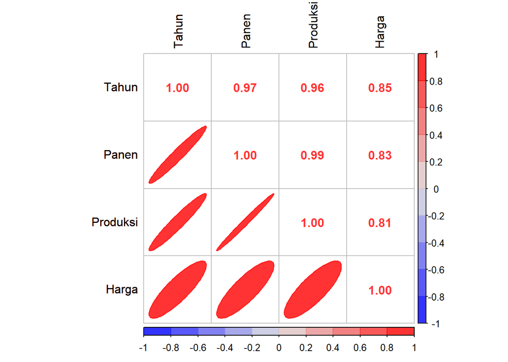

```r
#Membuat matriks korelasi
m <- cor(data_wine)

colors <- alpha(colorRampPalette(c("blue", #Warna Bawah
                                   "#dbdbdb", #Warna Tengah
                                   "red"))(10), #Warna Atas
                                   alpha = 0.80) #Transparan

corrplot(m, method = 'ellipse', type='lower', order='original', col=colors)
corrplot(m, add=TRUE, method = 'number', type='upper', order='original',
         tl.pos = "lt",
         tl.col = "black", col=colors)
```

Matriks korelasi di atas menunjukkan hubungan positif yang kuat antar semua peubah penjelas dengan peubah respon.

### Time Series Plot

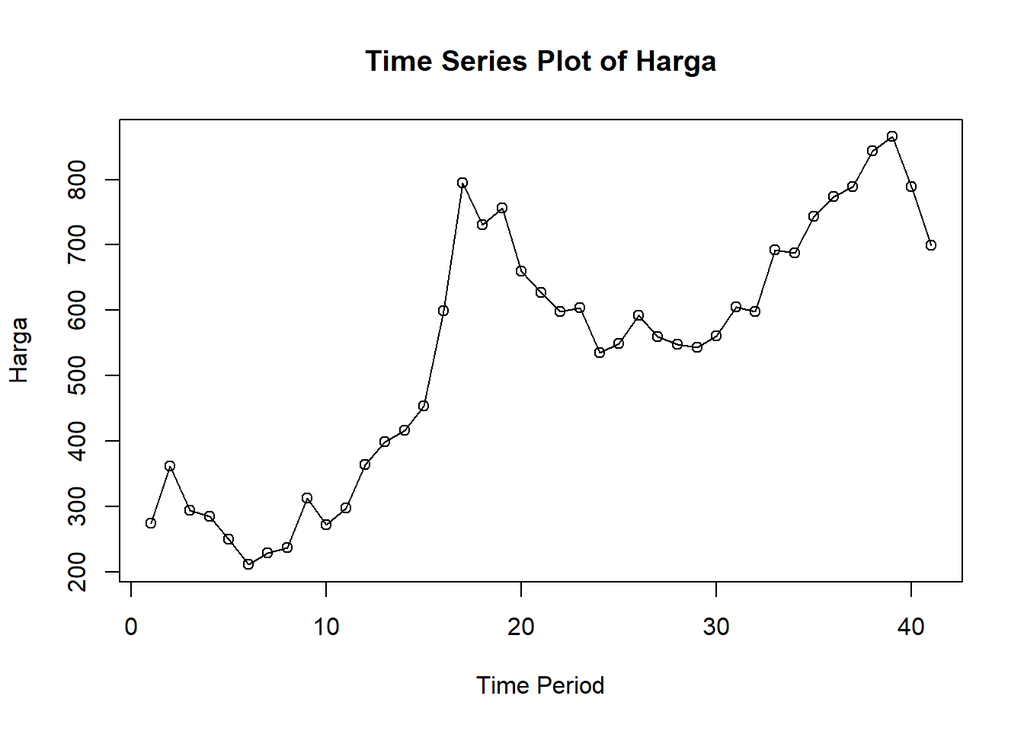

```r
#Membentuk objek time series
data_wine.ts <- ts(data_wine$Harga)

#Plot time series
ts.plot(data_wine.ts, xlab = "Time Period",
        ylab = "Harga",
        main = "Time Series Plot of Harga")
points(data_wine.ts)
```

Plot time series dari data wine berpola tren. Terlihat kenaikan dari tahun ke tahun pada peubah harga.

## Regresi

```r
#Pembuatan Model Regresi
#model regresi
model<- lm(Harga~Tahun+Panen+Produksi, data = data_wine)
summary(model)
```

```
##
## Call:
## lm(formula = Harga ~ Tahun + Panen + Produksi, data = data_wine)
##
## Residuals:
##     Min      1Q  Median      3Q     Max
## -136.54  -84.19  -12.62   34.30  286.14
##
## Coefficients:
##               Estimate Std. Error t value Pr(>|t|)
## (Intercept) -2.195e+04  1.063e+04  -2.064   0.0461 *
## Tahun        1.122e+01  5.358e+00   2.093   0.0432 *
## Panen        3.139e-02  2.331e-02   1.347   0.1863
## Produksi    -3.525e-03  2.810e-03  -1.254   0.2176
## ---
## Signif. codes:  0 '***' 0.001 '**' 0.01 '*' 0.05 '.' 0.1 ' ' 1
##
## Residual standard error: 104.4 on 37 degrees of freedom
## Multiple R-squared:  0.7391, Adjusted R-squared:  0.718
## F-statistic: 34.94 on 3 and 37 DF,  p-value: 6.878e-11
```

Selanjutnya dapat dilihat juga nilai $R^2=0.7391$. Artinya, sebesar 73.91% keragaman Harga wine dapat dijelaskan oleh peubah Tahun, Panen, dan Produksi. Hasil ini menunjukkan hasil yang bagus, seolah mendapatkan hasil terbaik. Namun, kita perlu melakukan uji terhadap sisaannya seperti berikut ini.

```r
#sisaan dan fitted value
sisaan<- residuals(model)
fitValue<- predict(model)
```

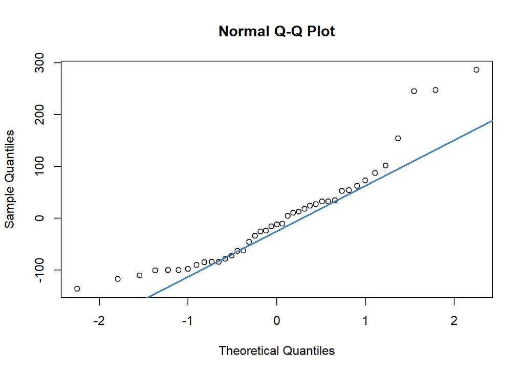

```r
#Diagnostik dengan eksploratif
par(mfrow = c(1,1))
qqnorm(sisaan)

#Normal Q-Q Plot
qqline(sisaan, col = "steelblue", lwd = 2)
```

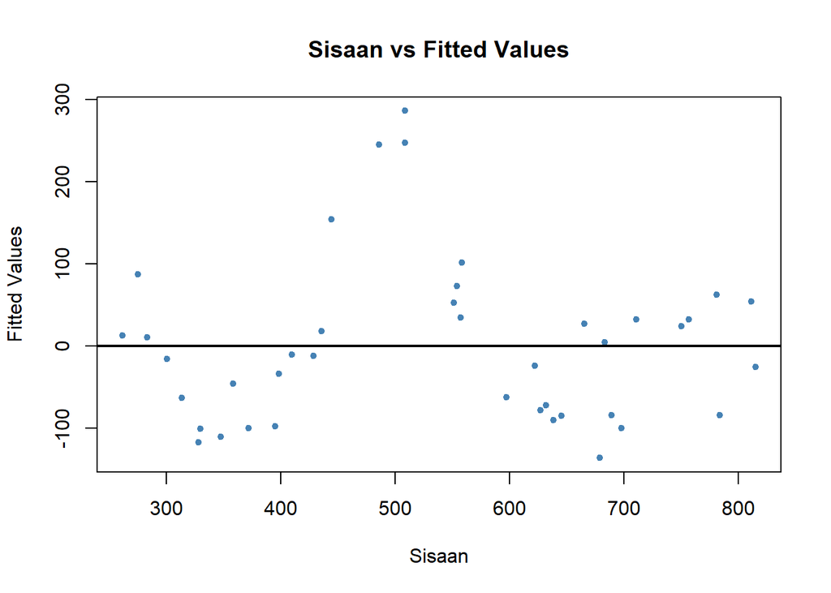

```r
plot(fitValue, sisaan, col = "steelblue", pch = 20, xlab = "Sisaan", ylab = "Fitted Values", main = "Sisaan vs Fitted Values")
abline(a = 0, b = 0, lwd = 2)
```

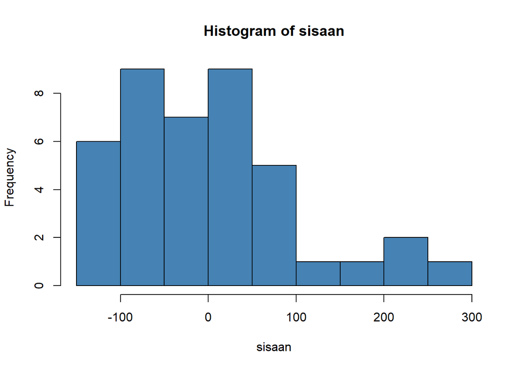

```r
#Histogram Sisaan
hist(sisaan, col = "steelblue")
```

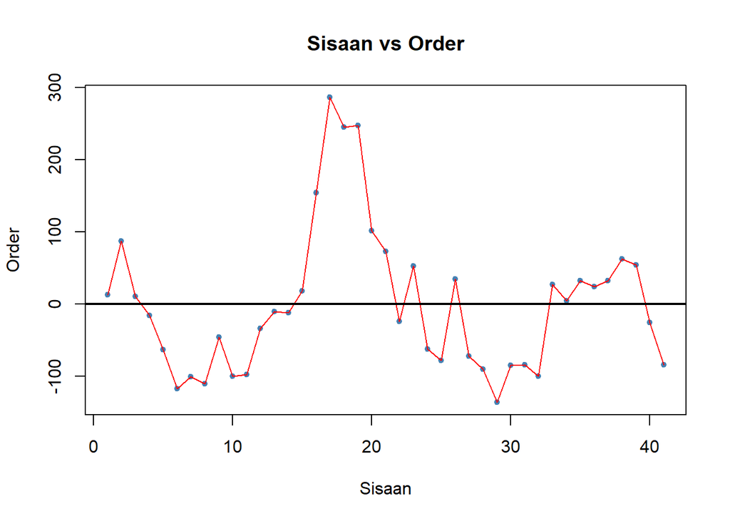

```r
plot(seq(1,41,1), sisaan, col = "steelblue", pch = 20, xlab = "Sisaan", ylab = "Order", main = "Sisaan vs Order")

lines(seq(1,41,1), sisaan, col = "red")
abline(a = 0, b = 0, lwd = 2)
```

Normal Q-Q Plot menunjukkan bahwa sisaan cenderung menyebar normal. Namun, histogram memperlihatkan sisaan cenderung positif skew. Plot antara sisaan vs order menunjukkan adanya autokorelasi karena ada pola antar sisaan.

## Uji Formal Normality Test

```r
#H0: sisaan mengikuti sebaran normal
#H1: sisaan tidak mengikuti sebaran normal
ks.test(sisaan, "pnorm", mean=mean(sisaan), sd=sd(sisaan))
```

```
##
##  Exact one-sample Kolmogorov-Smirnov test
##
## data:  sisaan
## D = 0.12241, p-value = 0.5306
## alternative hypothesis: two-sided
```

Berdasarkan tes normalitas menggunakan Kolmogorov-Smirnov Test didapatkan *p-value* > $\alpha$ (5%), artinya sisaan menyebar normal.

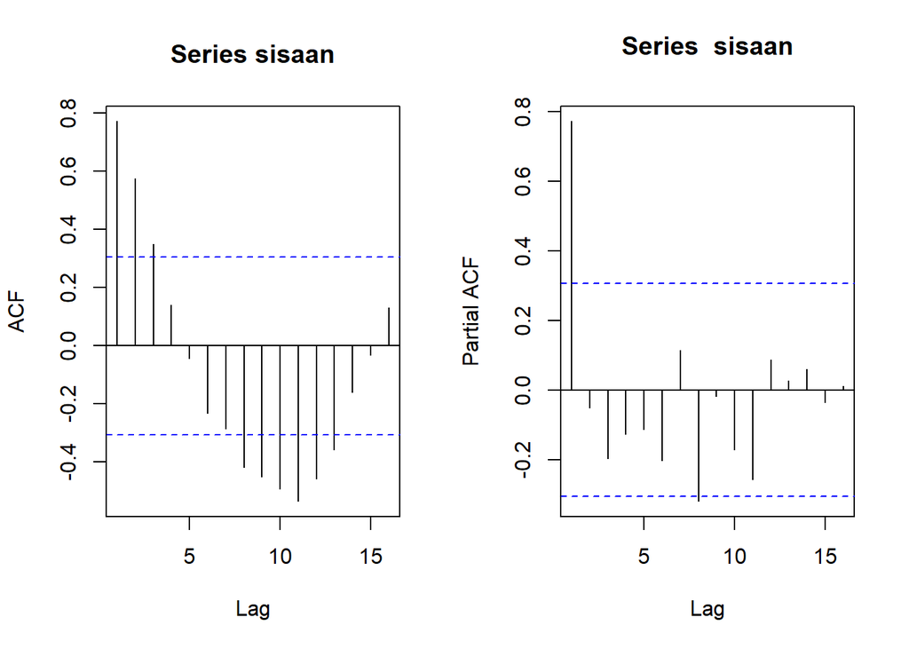

```r
#ACF dan PACF identifikasi autokorelasi
par(mfrow = c(1,2))
acf(sisaan)
pacf(sisaan)
```

Berdasarkan plot ACF dan PACF, terlihat bahwa bahwa garis melewati batas selang. Artinya, terjadi autokorelasi.

```r
#Deteksi autokorelasi dengan uji-Durbin Watson
#H0: tidak ada autokorelasi
#H1: ada autokorelasi
dwtest(model)
```

```
##
##  Durbin-Watson test
##
## data:  model
## DW = 0.43763, p-value = 1.211e-11
## alternative hypothesis: true autocorrelation is greater than 0
```

Hasil tes autokorelasi menggunakan Durbin-Watson Test memberikan nilai p-value < alpha 5%, artinya terjadi autokorelasi. Selain itu didapatkan nilai $DW = 0.43763$. Pada analisis ini $n = 41$ dan $k = 3$ sehingga nilai $DL = 1.3480$ dan $DU = 1.6603$. Artinya terjadi autokorelasi positif.

## Penanganan Autokorelasi

### Metode Cochrane-Orcutt

```r
#Penanganan Autokorelasi Cochrane-Orcutt
modelCO<-cochrane.orcutt(model)
modelCO
```

```
## Cochrane-orcutt estimation for first order autocorrelation
##
## Call:
## lm(formula = Harga ~ Tahun + Panen + Produksi, data = data_wine)
##
##  number of interaction: 6
##  rho 0.851873
##
## Durbin-Watson statistic
## (original):    0.43763 , p-value: 1.211e-11
## (transformed): 1.42581 , p-value: 2.522e-02
##
##  coefficients:
##   (Intercept)         Tahun         Panen      Produksi
## -37714.925547     19.166264     -0.009780     -0.000401
```

```r
dwtest(modelCO)
```

```
##
##  Durbin-Watson test
##
## data:  modelCO
## DW = 1.4258, p-value = 0.02522
## alternative hypothesis: true autocorrelation is greater than 0
```

```r
#Rho optimum
rho<- modelCO$rho
rho
```

```
## [1] 0.8518733
```

```r
#Transformasi Manual
Harga.trans<- data_wine$Harga[-1]-data_wine$Harga[-41]*rho
Tahun.trans<- data_wine$Tahun[-1]-data_wine$Tahun[-41]*rho
Panen.trans<- data_wine$Panen[-1]-data_wine$Panen[-41]*rho
Produksi.trans<- data_wine$Produksi[-1]-data_wine$Produksi[-41]*rho

modelCOmanual<- lm(Harga.trans~Tahun.trans+Panen.trans+Produksi.trans)
summary(modelCOmanual)
```

```
##
## Call:
## lm(formula = Harga.trans ~ Tahun.trans + Panen.trans + Produksi.trans)
##
## Residuals:
##    Min     1Q Median     3Q    Max
## -95.36 -26.87 -10.90  18.20 194.63
##
## Coefficients:
##                  Estimate Std. Error t value Pr(>|t|)
## (Intercept)    -5.587e+03  2.321e+03  -2.407   0.0213 *
## Tahun.trans     1.917e+01  7.848e+00   2.442   0.0196 *
## Panen.trans    -9.780e-03  1.369e-02  -0.714   0.4797
## Produksi.trans -4.009e-04  1.157e-03  -0.347   0.7309
## ---
## Signif. codes:  0 '***' 0.001 '**' 0.01 '*' 0.05 '.' 0.1 ' ' 1
##
## Residual standard error: 59.04 on 36 degrees of freedom
## Multiple R-squared:  0.154,  Adjusted R-squared:  0.08349
## F-statistic: 2.184 on 3 and 36 DF,  p-value: 0.1068
```

```r
#Mencari Penduga Koefisien Regresi setelah Transformasi ke Persamaan Awal
b0bintang <- modelCOmanual$coefficients[-c(2,3,4)]
b0 <- b0bintang/(1-rho)
b1 <- modelCOmanual$coefficients[-c(1,3,4)]
b2 <- modelCOmanual$coefficients[-c(1,2,4)]
b3 <- modelCOmanual$coefficients[-c(1,2,3)]
b0
```

```
## (Intercept)
##   -37714.93
```

```r
b1
```

```
## Tahun.trans
##    19.16626
```

```r
b2
```

```
##  Panen.trans
## -0.009779836
```

```r
b3
```

```
## Produksi.trans
##  -0.0004009116
```

Penanganan autokorelasi menggunakan fungsi dan manual menunjukkan hasil yang sama.

### Metode Hildreth-Lu

```r
#Penanganan Autokorelasi Hildreth lu
# Hildreth-Lu
hildreth.lu.func<- function(r, model){
  x1 <- model.matrix(model)[,2]
  x2 <- model.matrix(model)[,3]
  x3 <- model.matrix(model)[,4]

  y <- model.response(model.frame(model))
  n <- length(y)
  t <- 2:n

  y <- y[t]-r*y[t-1]
  x1 <- x1[t]-r*x1[t-1]
  x2 <- x2[t]-r*x2[t-1]
  x3 <- x3[t]-r*x3[t-1]

  return(lm(y~x1+x2+x3))
}

#Pencariab rho yang meminimumkan SSE
r <- c(seq(0.1,0.9, by= 0.1))
tab <- data.frame("rho" = r, "SSE" = sapply(r, function(i){deviance(hildreth.lu.func(i, model))}))
round(tab, 4)
```

```
##   rho      SSE
## 1 0.1 344250.2
## 2 0.2 292105.9
## 3 0.3 246724.0
## 4 0.4 208158.0
## 5 0.5 176540.8
## 6 0.6 152130.3
## 7 0.7 135333.5
## 8 0.8 126645.3
## 9 0.9 126491.2
```

```r
#Rho optimal di sekitar 0.4
rOpt <- seq(0.8,0.9, by= 0.001)
tabOpt <- data.frame("rho" = rOpt, "SSE" = sapply(rOpt, function(i){deviance(hildreth.lu.func(i, model))}))
head(tabOpt[order(tabOpt$SSE),])
```

```
##      rho      SSE
## 53 0.852 125480.8
## 52 0.851 125481.2
## 54 0.853 125481.4
## 51 0.850 125482.4
## 55 0.854 125482.8
## 50 0.849 125484.4
```

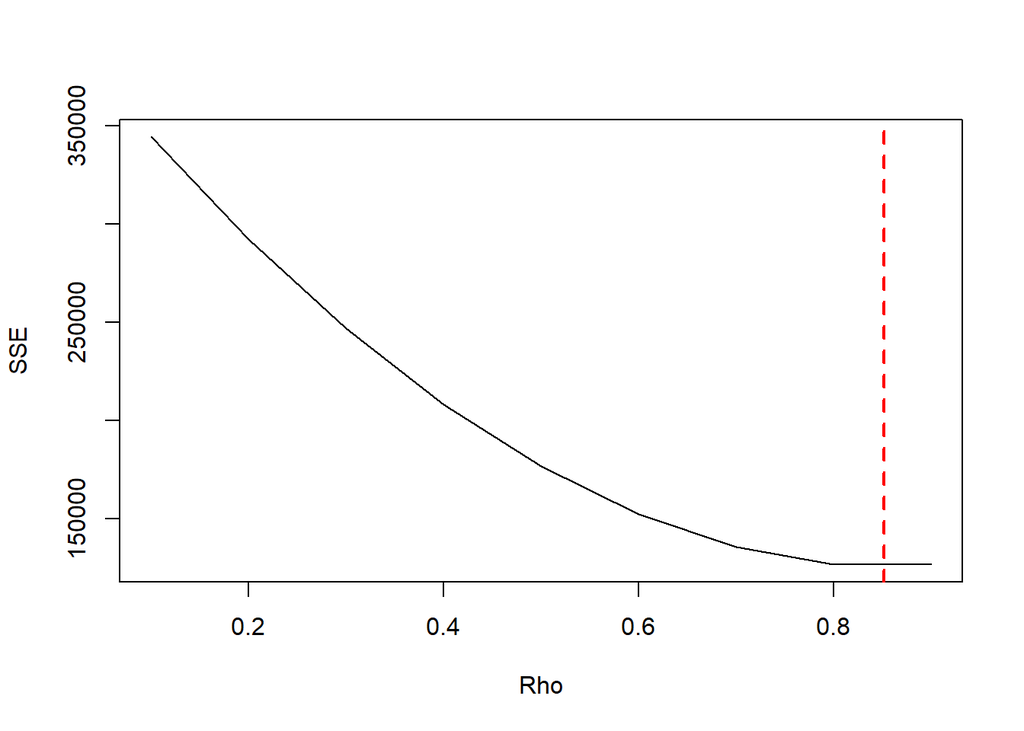

```r
#Grafik SSE optimum
par(mfrow = c(1,1))
plot(tab$SSE ~ tab$rho , type = "l", xlab = "Rho", ylab = "SSE")
abline(v = tabOpt[tabOpt$SSE==min(tabOpt$SSE),"rho"], lty = 2, col="red",lwd=2)
text(x=0.852, y=0.2397500, labels = "rho=0.341", cex = 0.8)
```

Perhitungan yang dilakukan aplikasi `R` menunjukkan bahwa nilai $ρ$ optimum, yaitu saat SSE terkecil terdapat pada nilai $ρ=0.852$. Hal tersebut juga ditunjukkan pada plot. Selanjutnya, model dapat didapatkan dengan mengevaluasi nilai $ρ$ ke dalam fungsi `hildreth.lu.func`, serta dilanjutkan dengan pengujian autokorelasi dengan uji Durbin-Watson. Namun, setelah pengecekan tersebut tidak lupa koefisien regresi tersebut digunakan untuk transformasi balik. Persamaan hasil transformasi itulah yang menjadi persamaan sesungguhnya.

```r
#Model terbaik
modelHL <- hildreth.lu.func(0.852, model)
summary(modelHL)
```

```
##
## Call:
## lm(formula = y ~ x1 + x2 + x3)
##
## Residuals:
##    Min     1Q Median     3Q    Max
## -95.36 -26.86 -10.89  18.20 194.62
##
## Coefficients:
##               Estimate Std. Error t value Pr(>|t|)
## (Intercept) -5.582e+03  2.320e+03  -2.406   0.0214 *
## x1           1.917e+01  7.852e+00   2.441   0.0197 *
## x2          -9.782e-03  1.369e-02  -0.714   0.4796
## x3          -4.008e-04  1.156e-03  -0.347   0.7309
## ---
## Signif. codes:  0 '***' 0.001 '**' 0.01 '*' 0.05 '.' 0.1 ' ' 1
##
## Residual standard error: 59.04 on 36 degrees of freedom
## Multiple R-squared:  0.1538, Adjusted R-squared:  0.08329
## F-statistic: 2.181 on 3 and 36 DF,  p-value: 0.1071
```

```r
#Transformasi Balik
cat("y = ", coef(modelHL)[1]/(1-0.852), "+", coef(modelHL)[2],"x1","+", coef(modelHL)[3],"x2","+", coef(modelHL)[4],"x3", sep = "")
```

```
## y = -37714.19+19.1659x1+-0.00978165x2+-0.0004007806x3
```

Setelah dilakukan tranformasi balik, didapatkan model dengan metode Hildreth-Lu sebagai berikut.
$$y_i=-37714.19+19.1659x_t-0.00978165x2-0.0004007806x3$$

```r
#Deteksi autokorelasi
dwtest(modelHL)
```

```
##
##  Durbin-Watson test
##
## data:  modelHL
## DW = 1.426, p-value = 0.02525
## alternative hypothesis: true autocorrelation is greater than 0
```

Terakhir, akan dibandingkan nilai SSE dari ketiga metode (metode awal, metode Cochrane-Orcutt, dan Hildreth-Lu).

```r
#Perbandingan
sseModelawal <- anova(model)$`Sum Sq`[-c(1,2,3)]
sseModelCO <- anova(modelCOmanual)$`Sum Sq`[-c(1,2,3)]
sseModelHL <- anova(modelHL)$`Sum Sq`[-c(1,2,3)]
mseModelawal <- sseModelawal/length(data_wine$Harga)
mseModelCO <- sseModelCO/length(data_wine$Harga)
mseModelHL <- sseModelHL/length(data_wine$Harga)
akurasi <- matrix(c(sseModelawal,sseModelCO,sseModelHL,
                    mseModelawal,mseModelCO,mseModelHL),nrow=2,ncol=3,byrow = T)
colnames(akurasi) <- c("Model Awal", "Model Cochrane-Orcutt", "Model Hildreth-Lu")
row.names(akurasi) <- c("SSE","MSE")
akurasi
```

```
##     Model Awal Model Cochrane-Orcutt Model Hildreth-Lu
## SSE 403335.477            125480.836        125480.843
## MSE   9837.451              3060.508          3060.508
```

Berdasarkan hasil tersebut dapat diketahui bahwa hasil penanganan autokorelasi dengan metode Cochrane-Orcutt dan Hildreth-Lu memiliki SSE yang sama, sebesar $125480.836$ dan lebih baik dibandingkan model awal ketika autokorelasi masih terjadi, yaitu sebesar $403335.477$.

# Simpulan